# beta

```python
from IPython.display import HTML

HTML('''<script>
code_show=true;
function code_toggle() {
 if (code_show){
 $('div.input').hide();
 } else {
 $('div.input').show();
 }
 code_show = !code_show
}
$( document ).ready(code_toggle);
</script>
<form action="javascript:code_toggle()"><input type="submit" value="Click here to toggle on/off the raw code."></form>''')
```

The total potential inside of a tidally perturbed star is

$\Phi'=\beta(r) U,$

where U is the external potential, and $\beta(r)$ corrects for the fluid displacements within the star.

The Lagrangian fluid displacement is

$\delta r = -\frac{\Phi'}{\partial_r \Phi_o}¸$ (a)

where $\Phi_o$ is the equilibrium potential. We also write the displacement as a sum over normal modes. Following the notation of Penoyre and Stone 2018

$\delta r= \Sigma_{nlm} \xi_{nl}(r) a_{nlm}(t) Y^m_{l} (\theta, \phi)$.

$a_{n l m}(t)=\frac{W_{\rm lm} Q_{\rm nl}}{\omega_{\rm nl}^2} \frac{G M_p}{R^2} \left(\frac{R}{D(t)}\right)^{l+1} e^{-i m \Phi(t)}$

We will only consider a single l here. Then,

$\delta r =-\Sigma_{nm} \frac{Q_{nl} \xi_{nl}(r)}{\omega_{nl}^2 r^l} R^{l-1} U_{lm}(r,\theta, \phi),$

where $U_{lm}$ is the $Y^m_{l}(\theta, \phi)$ component of the multipole expansion of U. Finally,

$\delta r =-\Sigma_{nm} \frac{Q_{nl} \xi_{nl}(r)}{\omega_{nl}^2 r^l} R^{l-1} \frac{G M_{\rm enc}(r)}{r^2} \frac{U_{lm}(r,\theta, \phi)}{\partial_r \Phi_o},$ (b)

Comparing equations a and b gives

$\beta_l(r) =\Sigma_{n} \frac{Q_{nl} \xi_{nl}(r)}{\omega_{nl}^2} \left(\frac{R}{r}\right)^{l-1} \frac{G M_{\rm enc}(r)}{r^3}$

If we write all quatities in "natural units" ($M_{\rm enc}$ and $r$ in in units of the stellar mass ($M_\star$) and radius ($R_\star$) respectively and $\omega^2$ in units of $G M_\star/R_\star^3$),

$\boxed{\beta_l (r)=\Sigma_n \frac{Q_{nl} \xi_{nl}(r)}{\omega_{nl}^2 r^{l+2}} M_{\rm enc}(r)}$

The plot below shows $\beta_2 (r)$ for an n=1.5 polytrope calculated from the above formula (*black line*) and from Poisson's equation (*dashed, red line*). We use the $\beta(10^{-3})=4.8$, $\beta'(10^{-3})=0$ as boundary conditions for the latter, to ensure the two solutions match near the center of the star.

```python
from ModeAnalyze import mode_analyze
reload(mode_analyze)
from scipy.interpolate import interp1d
%pylab inline

n_poly=1.5
prof=mode_analyze.n_poly(n_poly)
moda=mode_analyze.ModeAnalyzer(prof, '/home/aleksey/gyre_work/poly/{0}/poly'.format(n_poly), n_min=0, n_max=10, ls=[2])
rs=moda.modes_dict['0_2']['xs']
ms=interp1d(moda.rs, moda.ms)(rs)
```

```
0.999999999689 1.0
```

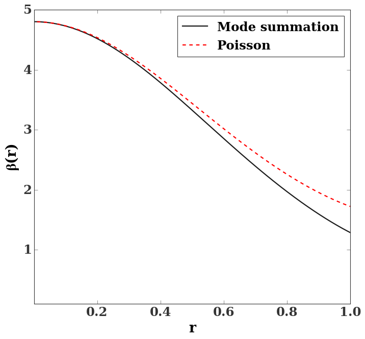

```python
fig,ax=plt.subplots(figsize=(10,9))
ax.set_ylim(0.1,5)
ax.set_xlim(0.001,1)
ax.set_xlabel('r')
ax.set_ylabel(r'$\beta(r)$')


plot(rs[1:], (abs(moda.beta_sum())*ms/rs**4)[1:], label='Mode summation')
dat=np.genfromtxt('/home/aleksey/gyre_work/poly/{0}/betaRun.tsv'.format(n_poly))
plot(dat[:,0], dat[:,1], 'r--', label='Poisson')
ax.legend()
```